# Fric et al. critiques: data curation

Elise Larsen & Vaughn Shirey

Updated 7-Dec-2020; Begun Feb-2020

### Here we explore the occurrence data from Fric et al. (2020)

This gives a detailed account of some data curation issues we observed in the Fric et al. data and curation. This file inputs the data/occurrence.RData and fric_supplements/ele13419-suo-0003-tables2.xlsx files and outputs the data/occurrences_FricAnalysis.RData

```r
rm(list=ls())
# load libraries
library(tidyverse)
library(readxl)
library(ggplot2)
library(ggExtra)
library(gridExtra)
# install.packages("viridis")
library(viridis)
```

### Data Input

We import the formatted occurrence data and explore the independent variables used in the Fric et al. analysis.

```r
#raw data
load("data/occurrences.RData")

#Revisit list of names from results file to limit data to that used by Fric et al.
#Which of these names shows up in the results?
result.names<-unique(na.omit(read_excel("fric_supplements/ele13419-sup-0003-tables2.xlsx", sheet="~latitude", range="A3:A113"))$Species)
resultnames<-(strsplit(result.names, " "))
result.names<-tibble(name=character(),genus=character(),spep=character())
for(i in 1:length(resultnames)) {
  genus<-paste(resultnames[[i]][1])
  spep<-paste(resultnames[[i]][2])
  name<-paste(genus,spep,sep=" ")
  temp.names<-tibble(name=as.character(name),genus=as.character(genus),spep=as.character(spep))
  result.names<-bind_rows(result.names,temp.names)
}
rm(resultnames, genus, spep, name, temp.names)

#Fric et al also removed all 1st of month observations according to their methods
fricdata<-filter(alldata, day!=1, name %in% result.names$name)
summary(fricdata)
```

[output not shown]

```r
#Save formatted and filtered occurrence data used by Fric et al.
save(fricdata,file="data/occurrences_FricAnalysis.RData")
```

### Data exploration: altitude (elevation)

(We defer to the Fric et al use of “altitude” for clarity)

Early on in data exploration we were concerned with the range of altitude values in the data. One aspect of our data exploration for altitude involved examining outliers and spot-checking specific occurrence records in GBIF, which were either below 0m or in the top quartile of altitudes. Looking at these records led us to understand that

- 1. GIS coordinates had often been assigned by placename, or were otherwise inaccurate, and
  2. 2. altitudes obtained by using the Google API to extract altitude for coordinates did not provide reliable altitudes for the underlying occurrences.

Here we examine broad patterns and specific outlier cases.

```r
#basic range & frequency in data
summary(fricdata$alt)
```

```
##     Min.  1st Qu.   Median     Mean  3rd Qu.     Max.
## -2666.74    23.25    64.24   114.26   109.48  4305.17
```

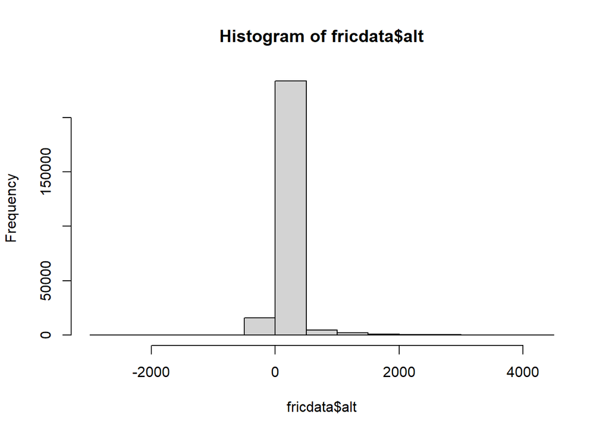

```r
hist(fricdata$alt)
```

```r
#how many records below 0?
print(paste(nrow(filter(fricdata,alt<0)),"records below sea level represent", round(nrow(filter(fricdata,alt<0))/nrow(fricdata)*100,2),"percent of all ocurrence records. We examined lat/long for many of these records and all examined locations were in bodies of water.",sep=" "))
```

```
## [1] "9974 records below sea level represent 3.87 percent of all ocurrence records. We examined lat/long for many of these records and all examined locations were in bodies of water."
```

```r
#how many records are above 500m?
print(paste(nrow(filter(fricdata,alt>500)),"records above 500m represent", round(nrow(filter(fricdata,alt>500))/nrow(fricdata)*100,2),"percent of all ocurrence records. We examined lat/long and location for a small subset of high altitude records and found vague place names had been used for geolocation.",sep=" "))
```

```
## [1] "8629 records above 500m represent 3.34 percent of all ocurrence records. We examined lat/long and location for a small subset of high altitude records and found vague place names had been used for geolocation."
```

```r
#How many in the 0-500m range
print(paste(nrow(filter(fricdata,between(alt,0,500))),"records  within 0-500m represent", round(nrow(filter(fricdata,between(alt,0,500)))/nrow(fricdata)*100,2),"percent of all ocurrence records. For reanalysis, we can constrain data to these records with minimal impact on data density. ",sep=" "))
```

```
## [1] "239369 records  within 0-500m represent 92.79 percent of all ocurrence records. For reanalysis, we can constrain data to these records with minimal impact on data density. "
```

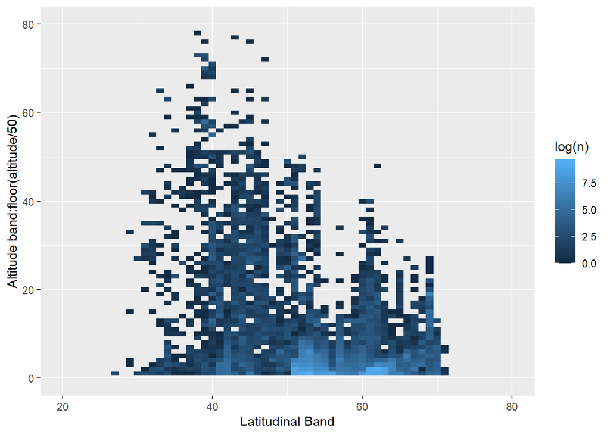

```r
altdata<-fricdata %>% mutate(alt.grp=floor(alt/50))  %>%
  group_by(alt.grp, rndLat) %>% tally()
# Heatmap
ggplot(altdata, aes(rndLat, alt.grp, fill= log(n))) +
  geom_tile() + labs(x="Latitudinal Band", y="Altitude band:floor(altitude/50)") +
  xlim(20,80) + ylim(0,80)
```

Outliers appear to be a problem with altitude. Reviewing GBIF records, this appears to be primarily due to the assumption by Fric et al. that the GIS coordinates are precise and that the google API would provide accurate and reliable altitude metrics. Based on the records we spot-checked, when GBIF includes elevation, the values do not match those used in the analysis.

- 1953 Anthocharis sara record (row.index 166; altitude -525.96m) is from https://www.gbif.org/occurrence/1039154960; geocoordinates were assigned via vertnet in 2015. These coordinates are located in the ocean. The GBIF record traces to https://collections.peabody.yale.edu/search/Record/YPM-ENT-729028 which simply gives a locality of “North America; USA; California; Los Angeles County; Rolling Hills”. Rolling Hills, CA is ~10km east of the given lat/long according to our estimation using googlemaps.
- 1991 Parnassius smintheus record (row.index 38; altitude 4048m) is from https://www.gbif.org/occurrence/1039027733 (which gives elevation of 3810m). The GBIF record traces to https://collections.peabody.yale.edu/search/Record/YPM-ENT-430824 which gives a locality of “North America; USA; Colorado; Summit County; Loveland Pass, 3810 m”. The actual collection altitude is provided by the source, and is different than that used in the analysis.
- 1918 Euphydryas chalcedona record (row.index 139; altitude 4305m) is the highest record in the data. It’s from https://www.gbif.org/occurrence/1039181223. The GBIF record traces to https://collections.peabody.yale.edu/search/Record/YPM-ENT-819202 which gives a locality of “North America; USA; California; Siskiyou County; Mount Shasta” There is a city named Mount Shasta, CA that incorporated in 1905 that is at elevation 1100m and the peak of Mount Shasta is 4320. It is unclear whether the locality refers to the mountain or to the city; either way it is unlikely that an altitude so close to the peak of the mountain is the best choice for this specimen.

So far those examples are all North America - does this problem exist in Europe too?

- A Lycaena hippothoe record from 1995 (row.index 2160; altitude 3274m) is from https://www.gbif.org/occurrence/2570253925 which lists an inferred elevation of 2000m.
- A Lycaena virgaureae record from 2002 (row.index 4501; altitude -85.8m) appears to match https://www.gbif.org/occurrence/173651704 which is located in the Gulf of Bothnia, though GBIF assigns an elevation of 0m. Considering the lat/long are (65,23) most likely those coordinates are imprecise.

### Altitude ~ Latitude collinearity

Fric et al. used regression of residuals for corrected analyses. Regression of residuals is not recommended, particularly if there could be collinearity among explanatory variables. We examined the collinearity by modeling rndLat ~ altitude and rndLat~ year, where rndLat represents the latitudinal bands used in analysis. The observed collinearity indicates that regression of residuals analyses would produce biased parameter estimates.

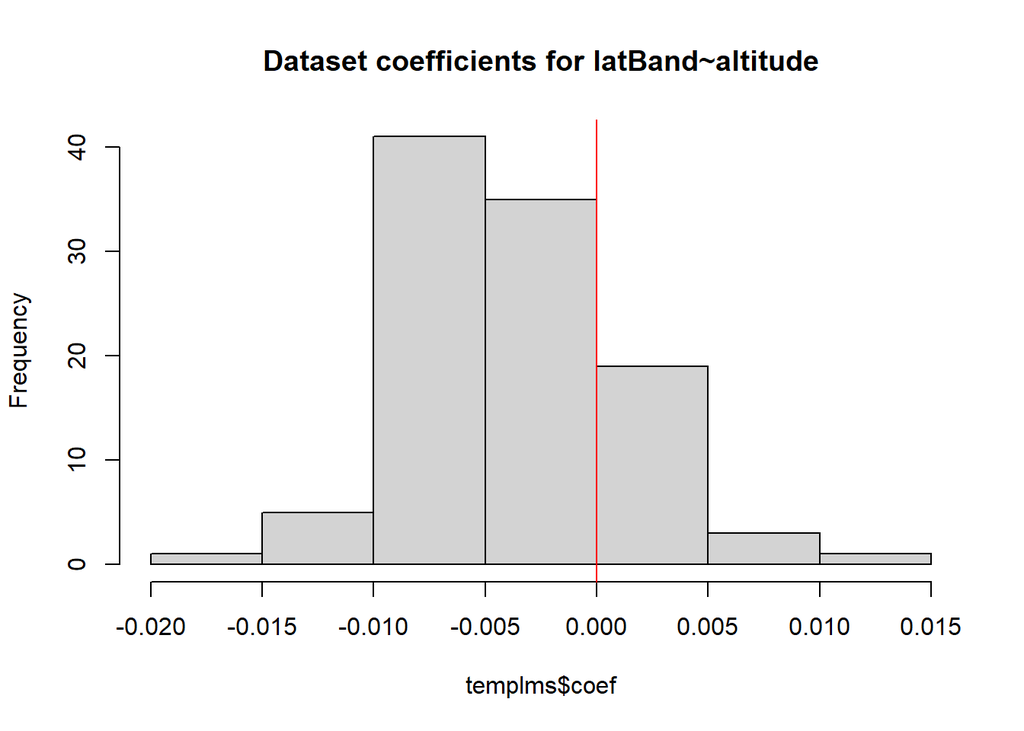

```r
#Additional issues with altitude
#Given the use of regression of residuals, we were concerned that collinearity among independent variables could have led to biased results.

#How many datasets have significant collinearity between altitude and latitude?
templms<-NULL
datasets<-fricdata %>% group_by(name, region)  %>% tally()
for (spi in 1:nrow(datasets)) {
  tempdata<-fricdata %>% filter(name==datasets$name[spi],region==datasets$region[spi])
  spilm<-summary(lm(rndLat~alt, data=tempdata))
  templms<-rbind(templms,c(nrow(tempdata), spilm$coefficients[2,1],  spilm$coefficients[2,4], spilm$r.squared))
}
templms<-as.data.frame(templms)
names(templms)<-c("n","coef","pval","r2")
hist(templms$coef, main="Dataset coefficients for latBand~altitude")
abline(v=0,col="red")
```

```r
summary(templms)
```

```
##        n              coef                pval               r2
##  Min.   :   15   Min.   :-0.019376   Min.   :0.00000   Min.   :0.0000222
##  1st Qu.:   78   1st Qu.:-0.006861   1st Qu.:0.00000   1st Qu.:0.0280076
##  Median :  189   Median :-0.004516   Median :0.00000   Median :0.1909175
##  Mean   : 2457   Mean   :-0.003832   Mean   :0.06654   Mean   :0.2824787
##  3rd Qu.: 1067   3rd Qu.:-0.001088   3rd Qu.:0.00851   3rd Qu.:0.5261002
##  Max.   :51819   Max.   : 0.014635   Max.   :0.86050   Max.   :0.8487862
```

```r
round(nrow(filter(templms,pval<0.05))/nrow(templms),2)
```

```
## [1] 0.85
```

```r
#How many datasets have significant collinearity
print(paste(nrow(filter(templms,pval<0.05)),"datasets have significant collinearity, representing", round(nrow(filter(templms,pval<0.05))/nrow(templms)*100,1),"percent of all datasets. For datasets with significant collinearity, the mean coefficient is",round(mean(templms$coef[templms$pval<0.05]),3),"(which translates to a slope of", round(1/mean(templms$coef[templms$pval<0.05]),0),"meters per degree latitude) and mean r-squared is",round(mean(templms$r2[templms$pval<0.05]),3)," - therefore regression of residuals is likely producing bias parameters.",sep=" "))
```

[output not shown]

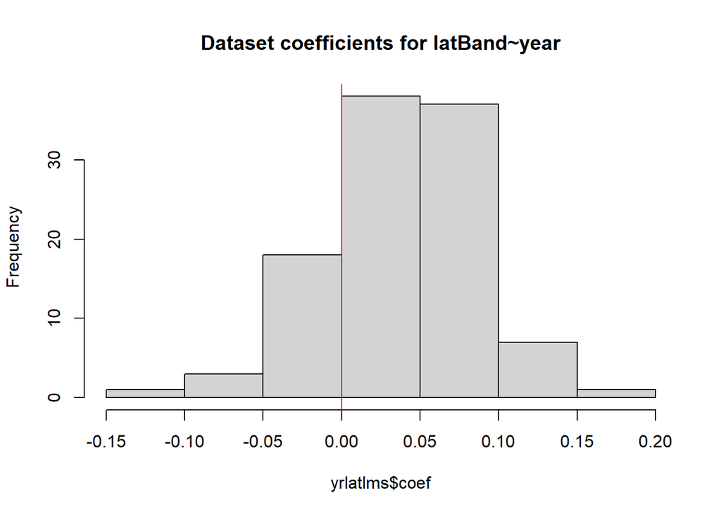

```r
#How many datasets have significant collinearity between year and latitude?
yrlatlms<-NULL
for (spi in 1:nrow(datasets)) {
  tempdata<-fricdata %>% filter(name==datasets$name[spi],region==datasets$region[spi])
  spilm<-summary(lm(rndLat~year, data=tempdata))
  yrlatlms<-rbind(yrlatlms,c(nrow(tempdata), spilm$coefficients[2,1],  spilm$coefficients[2,4], spilm$r.squared))
}
yrlatlms<-as.data.frame(yrlatlms)
names(yrlatlms)<-c("n","coef","pval","r2")
hist(yrlatlms$coef, main="Dataset coefficients for latBand~year")
abline(v=0,col="red")
```

```r
summary(yrlatlms)
```

```
##        n              coef                pval                r2
##  Min.   :   15   Min.   :-0.105938   Min.   :0.000000   Min.   :0.0000001
##  1st Qu.:   78   1st Qu.: 0.008515   1st Qu.:0.000000   1st Qu.:0.0132368
##  Median :  189   Median : 0.040297   Median :0.004441   Median :0.0507987
##  Mean   : 2457   Mean   : 0.039126   Mean   :0.142946   Mean   :0.0907969
##  3rd Qu.: 1067   3rd Qu.: 0.074053   3rd Qu.:0.123499   3rd Qu.:0.1258460
##  Max.   :51819   Max.   : 0.179087   Max.   :0.992704   Max.   :0.6066502
```

```r
round(nrow(filter(yrlatlms,pval<0.05))/nrow(yrlatlms),2)
```

```
## [1] 0.62
```

```r
#How many datasets have significant collinearity
print(paste(nrow(filter(yrlatlms,pval<0.05)),"datasets have significant collinearity, representing", round(nrow(filter(yrlatlms,pval<0.05))/nrow(yrlatlms)*100,1),"percent of all datasets. For datasets with significant collinearity, the mean coefficient is",round(mean(yrlatlms$coef[yrlatlms$pval<0.05]),3),"and mean r-squared is",round(mean(yrlatlms$r2[yrlatlms$pval<0.05]),3),".",sep=" "))
```

```
## [1] "65 datasets have significant collinearity, representing 61.9 percent of all datasets. For datasets with significant collinearity, the mean coefficient is 0.058 and mean r-squared is 0.135 ."
```

### Data exploration: data density

- In Fric et al. (2020), datasets were analysed with as few as 15 ocurrence records.
- We examine the prevalence of singleton ocurrences, when just one ocurrence was available in a latitudinal band.

```r
lat.summary1<-fricdata %>%
  group_by(name, region, rndLat) %>%
  summarize(lat.samplesize=n(),singleton=ifelse(lat.samplesize==1,1,0),dur=max(SuccDay)-min(SuccDay))
lat.summary2<-lat.summary1 %>%
  group_by(name,region) %>%
  summarize(samplesize=sum(lat.samplesize),latspan=max(rndLat)-min(rndLat),nlats=length(unique(rndLat)),n.singletons=sum(singleton),prop.singletons=n.singletons/nlats)
summary(lat.summary2)
```

```
##      name              region            samplesize       latspan
##  Length:105         Length:105         Min.   :   15   Min.   :10.0
##  Class :character   Class :character   1st Qu.:   78   1st Qu.:24.0
##  Mode  :character   Mode  :character   Median :  189   Median :27.0
##                                        Mean   : 2457   Mean   :26.3
##                                        3rd Qu.: 1067   3rd Qu.:30.0
##                                        Max.   :51819   Max.   :64.0
##      nlats       n.singletons    prop.singletons
##  Min.   : 5.0   Min.   : 0.000   Min.   :0.00000
##  1st Qu.:13.0   1st Qu.: 2.000   1st Qu.:0.09375
##  Median :18.0   Median : 3.000   Median :0.19048
##  Mean   :18.9   Mean   : 3.429   Mean   :0.20831
##  3rd Qu.:25.0   3rd Qu.: 5.000   3rd Qu.:0.33333
##  Max.   :33.0   Max.   :10.000   Max.   :0.60000
```

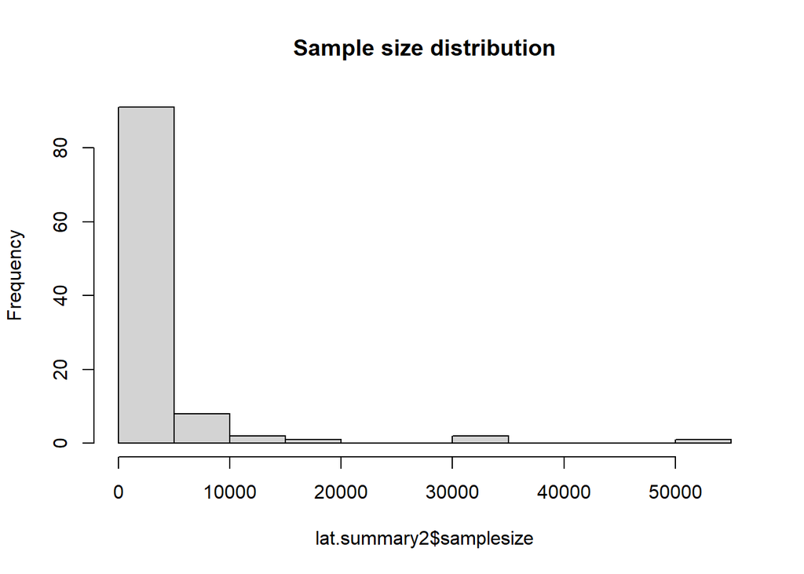

```r
#Visualize range of sample sizes
hist(lat.summary2$samplesize, main="Sample size distribution")
```

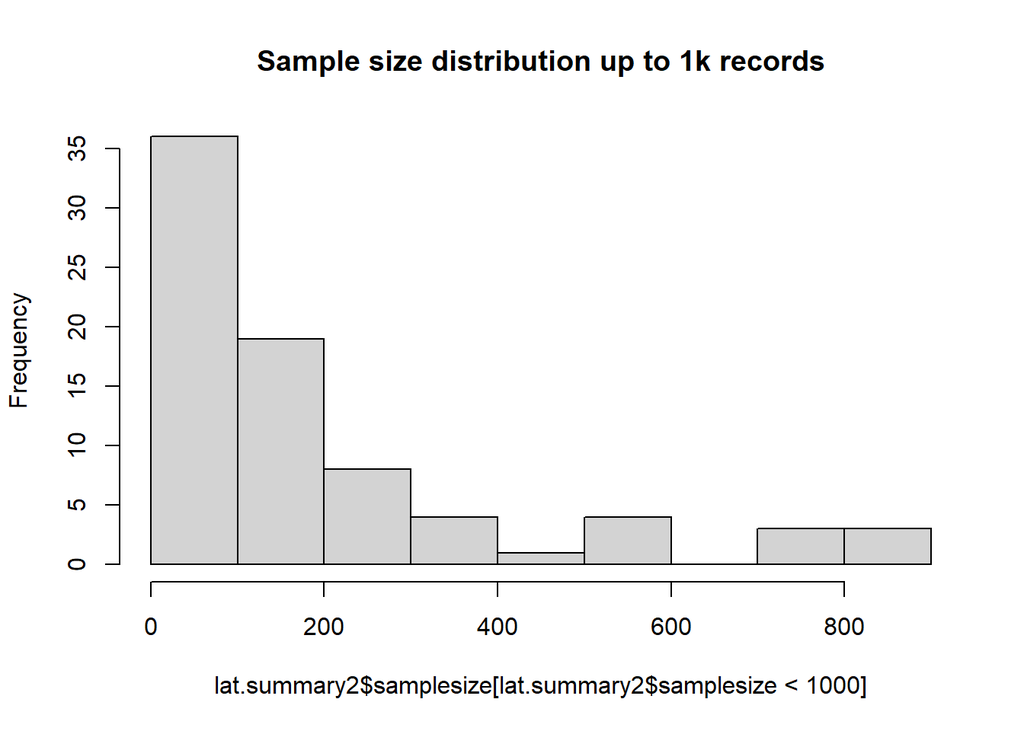

```r
#look at the lower end of sample sizes, where most datasets are
hist(lat.summary2$samplesize[lat.summary2$samplesize<1000], main="Sample size distribution up to 1k records")
```

```r
nrow(lat.summary2 %>% filter(samplesize<100))
```

```
## [1] 36
```

```r
print(paste(nrow(lat.summary2 %>% filter(samplesize<100)),"datasets have less than 100 ocurrence records."))
```

```
## [1] "36 datasets have less than 100 ocurrence records."
```

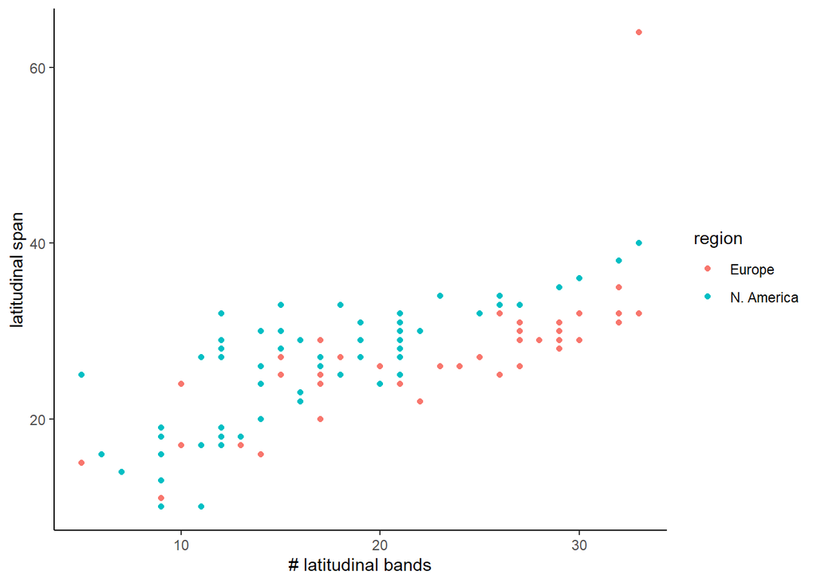

```r
ggplot(data=lat.summary2, aes(x=nlats, y=latspan, color=region)) + geom_point() + theme_classic() +
  labs(x="# latitudinal bands", y="latitudinal span")
```

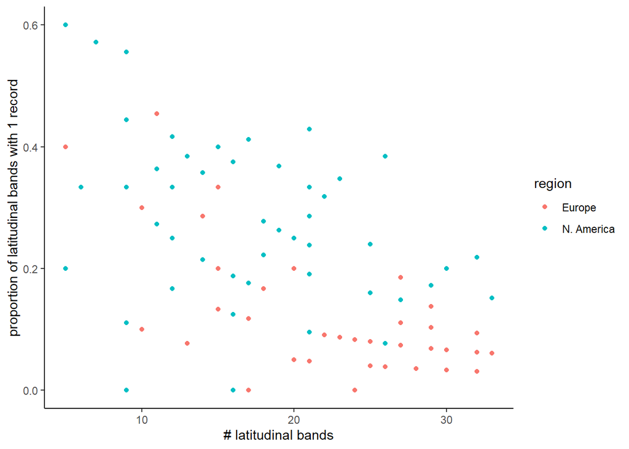

```r
ggplot(data=lat.summary2, aes(x=nlats, y=prop.singletons, color=region)) + geom_point() + theme_classic() +
  labs(x="# latitudinal bands", y="proportion of latitudinal bands with 1 record")
```

### Data exploration: year

As expected, most data are quite recent. By selecting the min and max day of year per latitudinal band as onset & termination, the authors vastly decrease their sample size and remove most of the variation along the year and altitude axes

We arbitrarily selected one species with a low sample size and one species with a large sample size, to visualize.

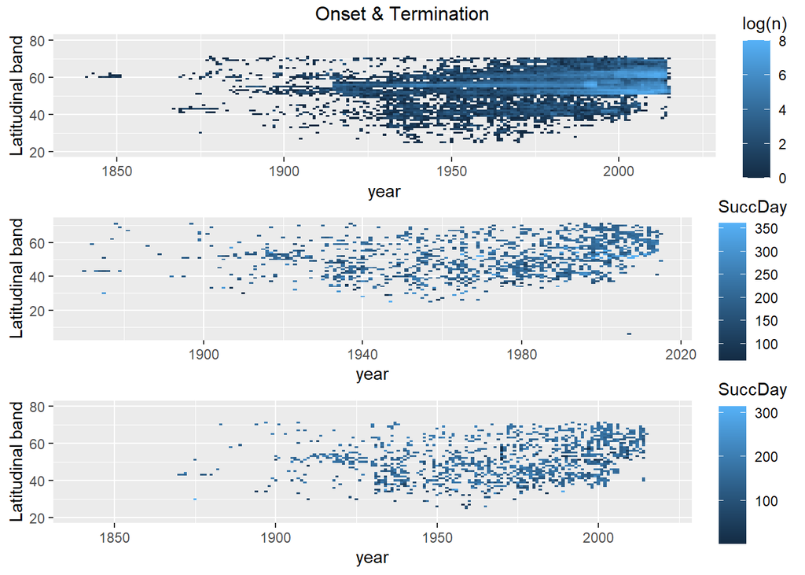

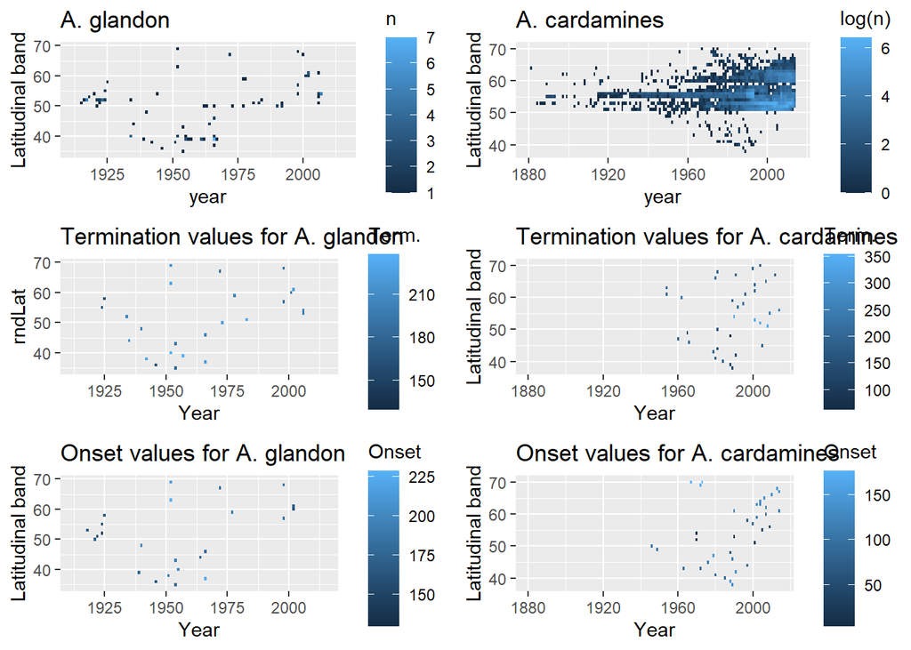

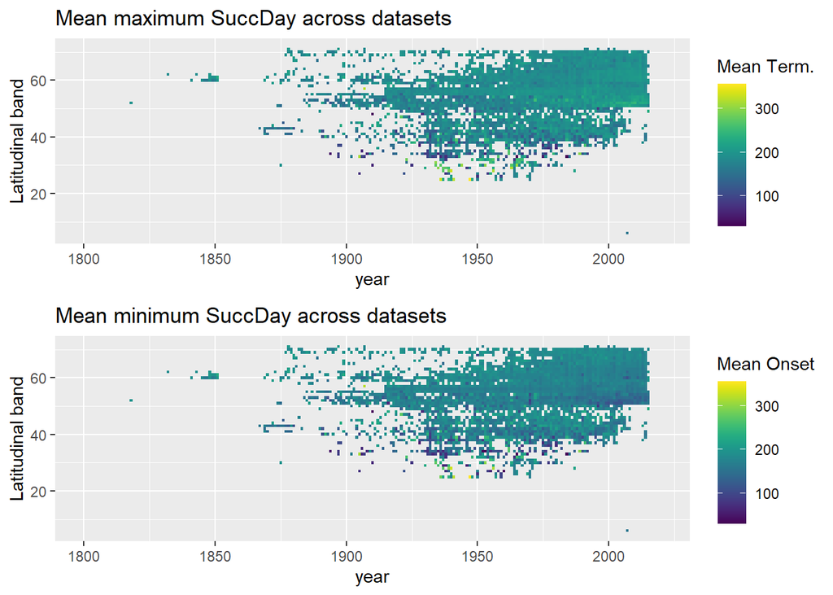

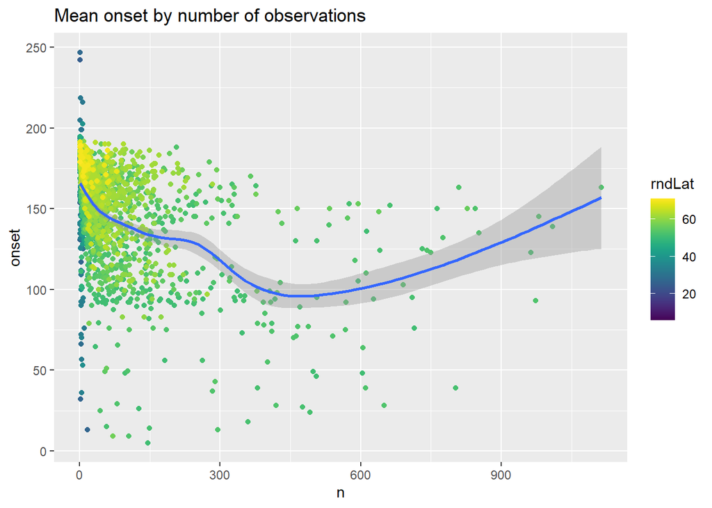

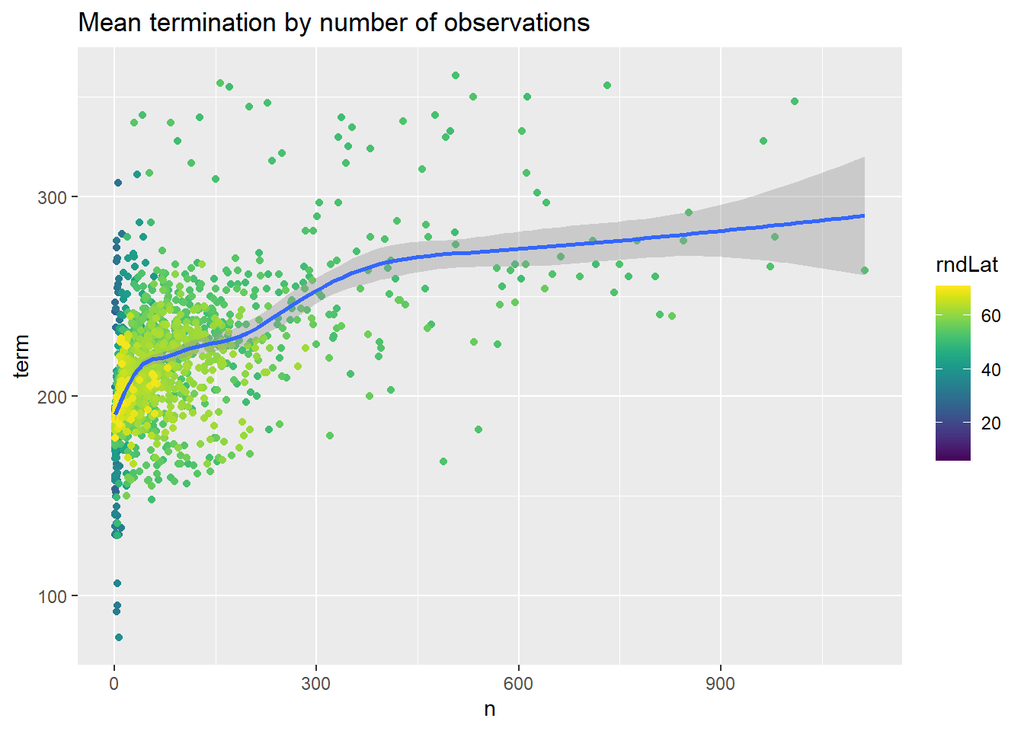

End of File.